# DEFENSIVE TRAITS P.lagopus SIBECOL 2025

Andrés Delgado Galán

2025-05-18

### P.lagopus - PRODUCCIÓN DE FLORES

**flor ~ trat + clip + trat:clip**  
n = **16** (muchos 0s quitados)

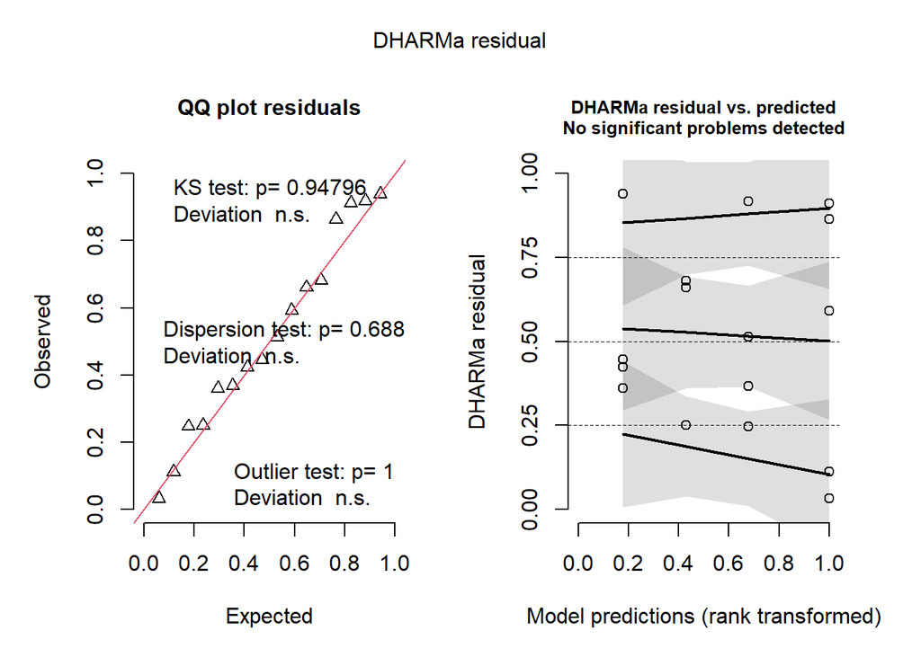

##### PLflor Post-hoc Comparisons with Tukeys HSD

| contrast | trat | estimate | SE | df | z.ratio | p.value |
| --- | --- | --- | --- | --- | --- | --- |
| no - yes | ex | 0.4274436 | 0.4366275 | Inf | 0.9789663 | 0.3275966 |
| no - yes | gra | 0.3899609 | 0.4404978 | Inf | 0.8852733 | 0.3760093 |

| contrast | clip | estimate | SE | df | z.ratio | p.value |
| --- | --- | --- | --- | --- | --- | --- |
| ex - gra | no | -0.1070980 | 0.3836366 | Inf | -0.2791653 | 0.7801180 |
| ex - gra | yes | -0.1445807 | 0.4873447 | Inf | -0.2966703 | 0.7667182 |

ANOVA Results for PLflor Model

| Response | Predictor | Chisq | Df | Pr(>Chisq) |
| --- | --- | --- | --- | --- |
| PL flor | trat | 0.162 | 1 | 0.687 |
| PL flor | clip | 1.738 | 1 | 0.187 |
| PL flor | trat:clip | 0.004 | 1 | 0.952 |

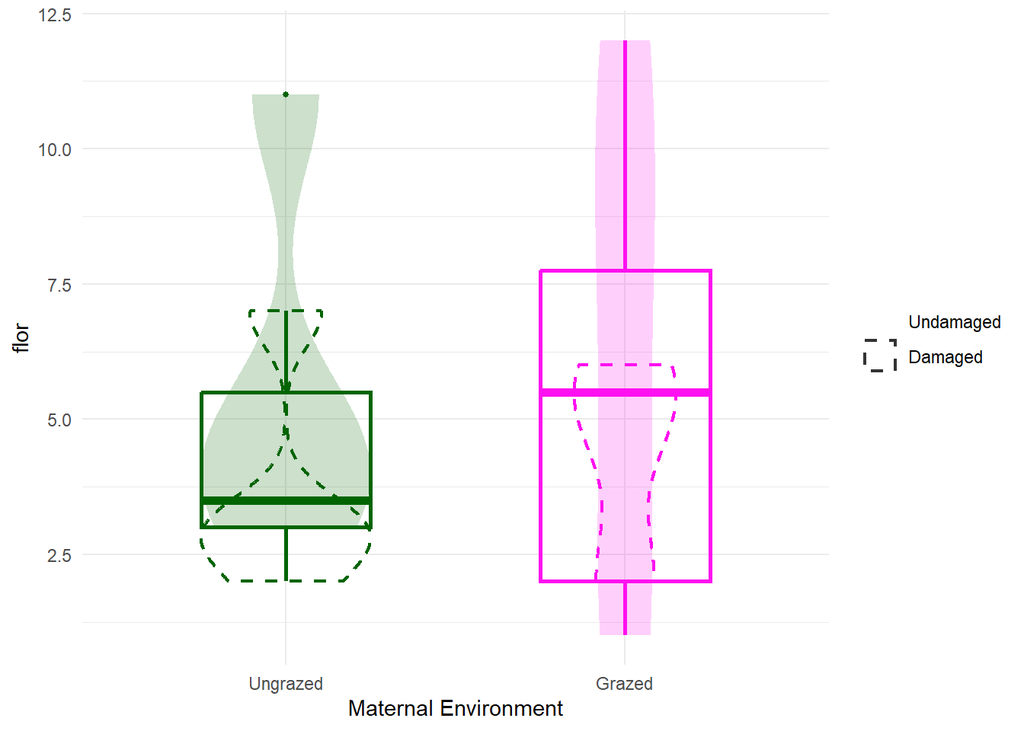

### P.lagopus - PRODUCCIÓN DE FRUTOS

**fruto ~ trat + clip + trat:clip**  
n = **12** (muchos 0s quitados)

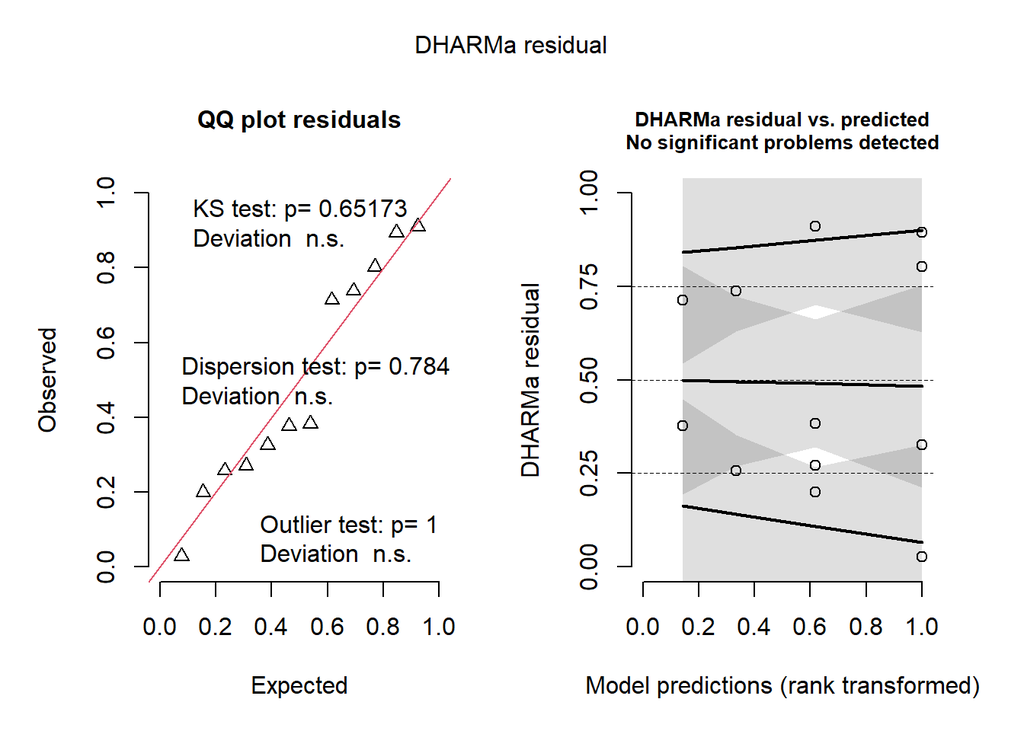

##### PLfruto Post-hoc Comparisons with Tukeys HSD

| contrast | trat | estimate | SE | df | z.ratio | p.value |
| --- | --- | --- | --- | --- | --- | --- |
| no - yes | ex | 0.5306261 | 0.5361985 | Inf | 0.9896075 | 0.3223660 |
| no - yes | gra | 0.5596171 | 0.4929211 | Inf | 1.1353076 | 0.2562464 |

| contrast | clip | estimate | SE | df | z.ratio | p.value |
| --- | --- | --- | --- | --- | --- | --- |
| ex - gra | no | -0.2113108 | 0.3543533 | Inf | -0.5963282 | 0.5509560 |
| ex - gra | yes | -0.1823198 | 0.6363284 | Inf | -0.2865184 | 0.7744811 |

ANOVA Results for PLfruto Model

| Response | Predictor | Chisq | Df | Pr(>Chisq) |
| --- | --- | --- | --- | --- |
| PL fruto | trat | 0.436 | 1 | 0.509 |
| PL fruto | clip | 2.267 | 1 | 0.132 |
| PL fruto | trat:clip | 0.002 | 1 | 0.968 |

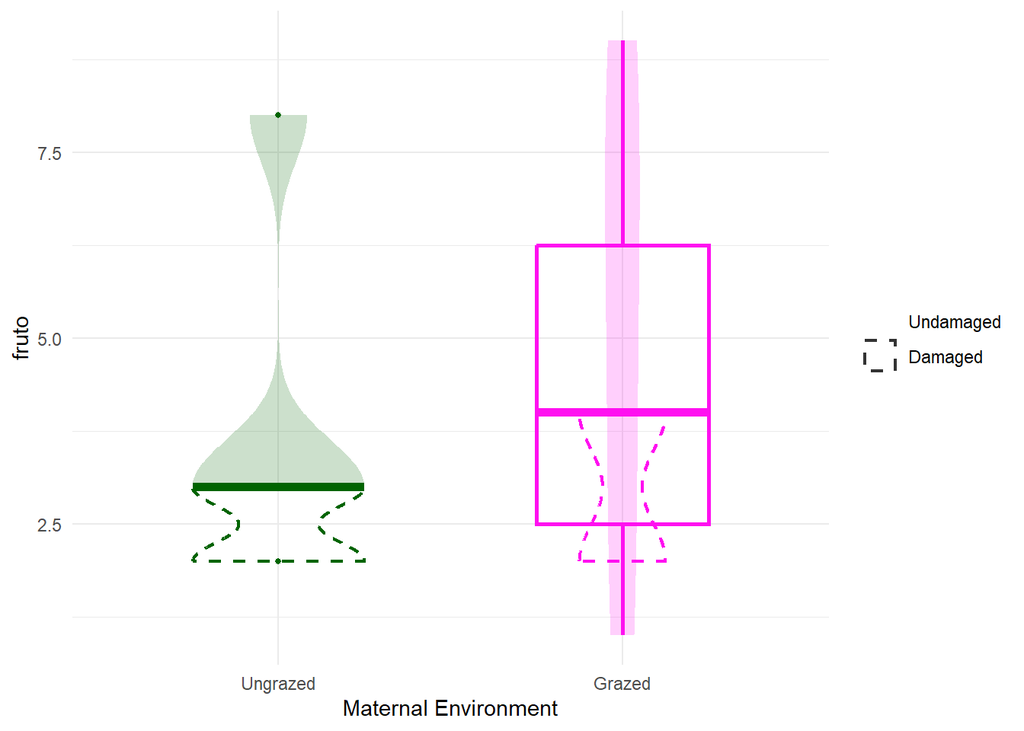

### P.lagopus - PRODUCCIÓN DE HOJAS

**hojas ~ trat + clip + trat:clip**  
n = **52**

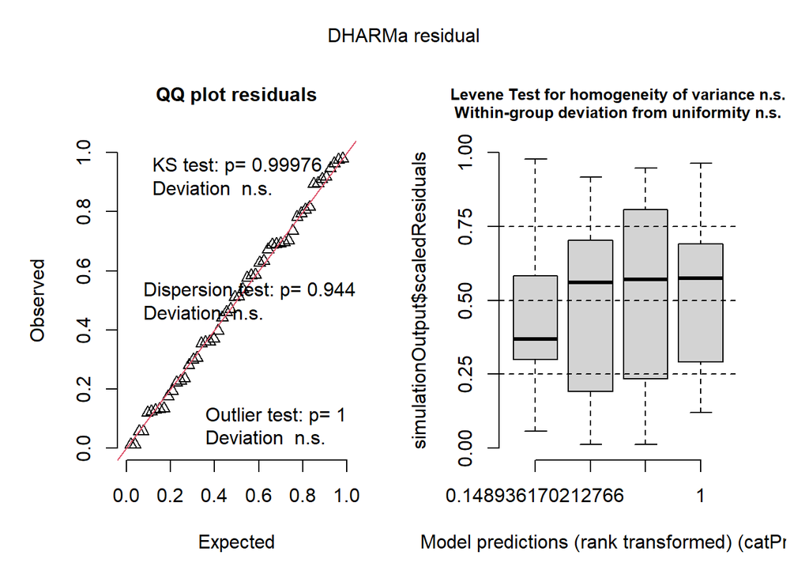

##### PLhojas Post-hoc Comparisons with Tukeys HSD

| contrast | trat | estimate | SE | df | z.ratio | p.value |
| --- | --- | --- | --- | --- | --- | --- |
| no - yes | ex | -0.2015735 | 0.1101379 | Inf | -1.830192 | 0.0672212 |
| no - yes | gra | 0.1634663 | 0.1063521 | Inf | 1.537029 | 0.1242861 |

| contrast | clip | estimate | SE | df | z.ratio | p.value |
| --- | --- | --- | --- | --- | --- | --- |
| ex - gra | no | -0.1443179 | 0.1040899 | Inf | -1.386474 | 0.1656023 |
| ex - gra | yes | 0.2207219 | 0.1122783 | Inf | 1.965847 | 0.0493163 |

ANOVA Results for PLhojas Model

| Response | Predictor | Chisq | Df | Pr(>Chisq) |
| --- | --- | --- | --- | --- |
| PL hojas | trat | 0.102 | 1 | 0.749 |
| PL hojas | clip | 0.027 | 1 | 0.868 |
| PL hojas | trat:clip * | 5.685 | 1 | 0.017 |

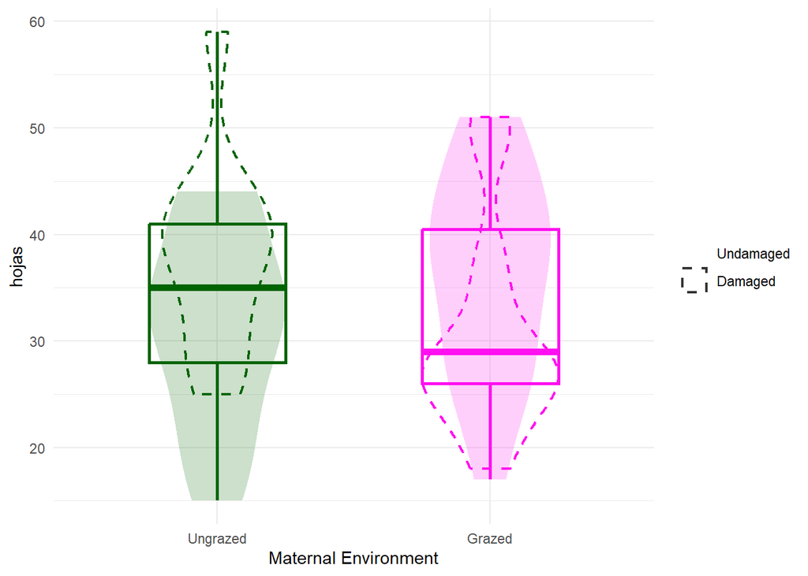

### P.lagopus - ALTURA MÁXIMA

**altura ~ trat + clip + trat:clip**  
n = **17**

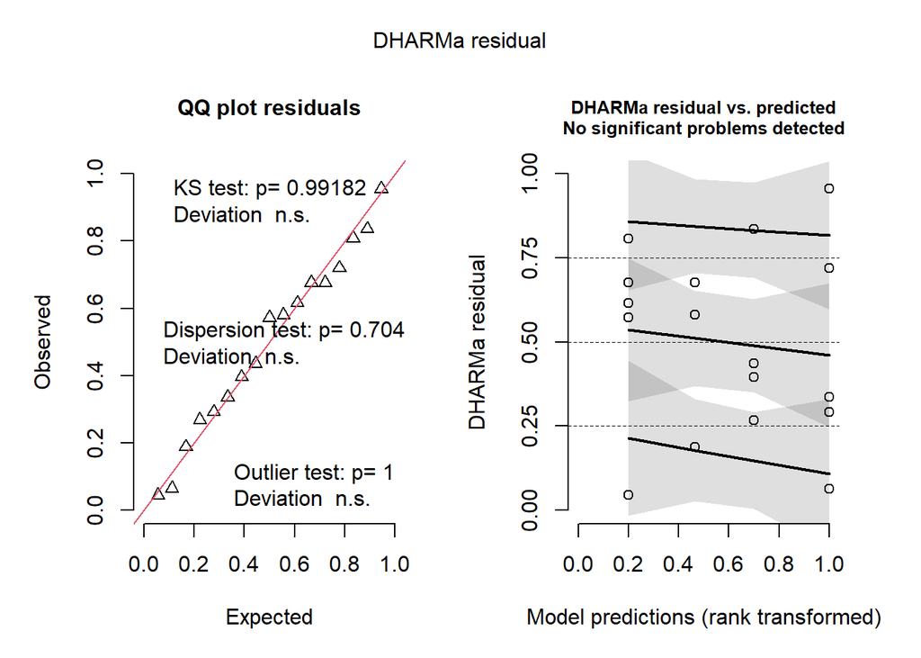

R² = **0.1338671**

##### PLaltura Post-hoc Comparisons with Tukeys HSD

| contrast | trat | estimate | SE | df | t.ratio | p.value |
| --- | --- | --- | --- | --- | --- | --- |
| no - yes | ex | 7.500000 | 6.571003 | 13 | 1.141378 | 0.2743019 |
| no - yes | gra | 8.733333 | 7.153602 | 13 | 1.220830 | 0.2438313 |

| contrast | clip | estimate | SE | df | t.ratio | p.value |
| --- | --- | --- | --- | --- | --- | --- |
| ex - gra | no | -6.900000 | 6.571003 | 13 | -1.0500680 | 0.3128163 |
| ex - gra | yes | -5.666667 | 7.153602 | 13 | -0.7921418 | 0.4424937 |

ANOVA Results for PLaltura Model

| Response | Predictor | Sum Sq | Df | F value | Pr(>F) |
| --- | --- | --- | --- | --- | --- |
| PL altura | trat | 164.461 | 1 | 1.714 | 0.213 |
| PL altura | clip | 266.461 | 1 | 2.777 | 0.120 |
| PL altura | trat:clip | 1.547 | 1 | 0.016 | 0.901 |
| PL altura | Residuals | 1247.367 | 13 | NA | NA |

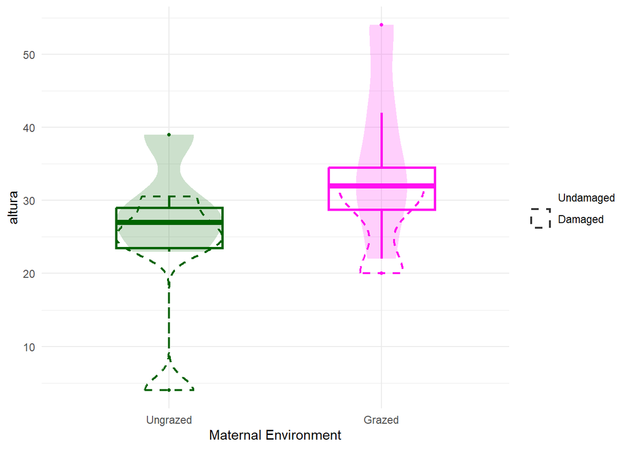

### P.lagopus - SEMILLAS/FRUTO

**seedfruto ~ trat + clip + trat:clip**  
n = **9**

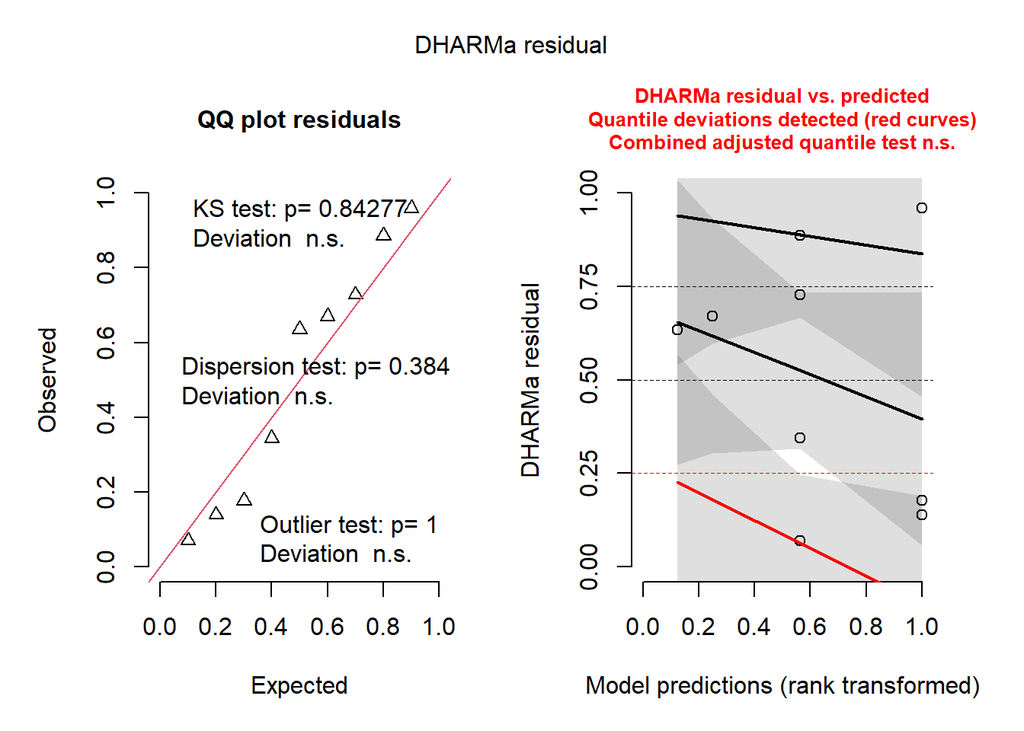

##### PLseedfruto Post-hoc Comparisons with Tukeys HSD

| contrast | trat | estimate | SE | df | z.ratio | p.value |
| --- | --- | --- | --- | --- | --- | --- |
| no - yes | ex | -0.4855068 | 0.8148405 | Inf | -0.5958305 | 0.5512885 |
| no - yes | gra | 0.5935779 | 0.8095162 | Inf | 0.7332502 | 0.4634059 |

| contrast | clip | estimate | SE | df | z.ratio | p.value |
| --- | --- | --- | --- | --- | --- | --- |
| ex - gra | no | -0.2188836 | 0.7917750 | Inf | -0.2764467 | 0.7822050 |
| ex - gra | yes | 0.8602011 | 0.8320901 | Inf | 1.0337837 | 0.3012373 |

ANOVA Results for PLseedfruto Model

| Response | Predictor | Chisq | Df | Pr(>Chisq) |
| --- | --- | --- | --- | --- |
| PL seedfruto | trat | 0.263 | 1 | 0.608 |
| PL seedfruto | clip | 0.010 | 1 | 0.920 |
| PL seedfruto | trat:clip | 0.883 | 1 | 0.347 |

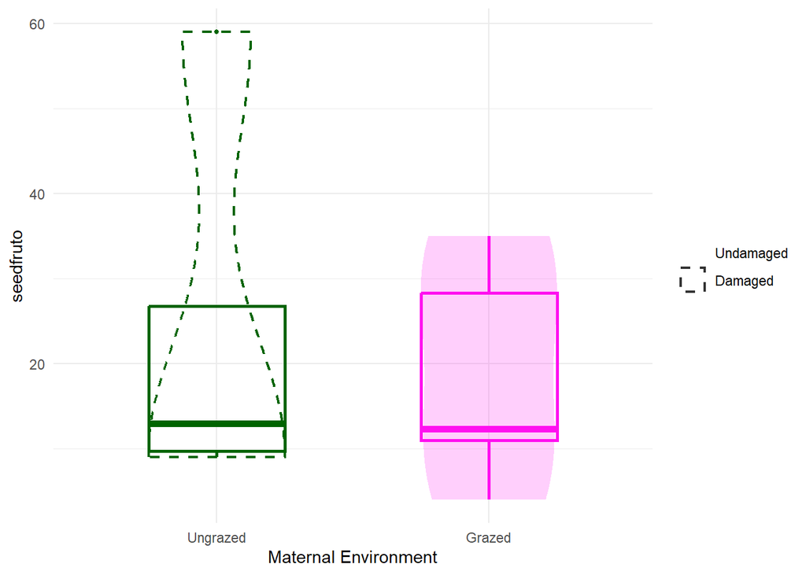

### P.lagopus - PRODUCCIÓN DE SEMILLAS

**seedtotal ~ trat + clip + trat:clip**  
n = **11**

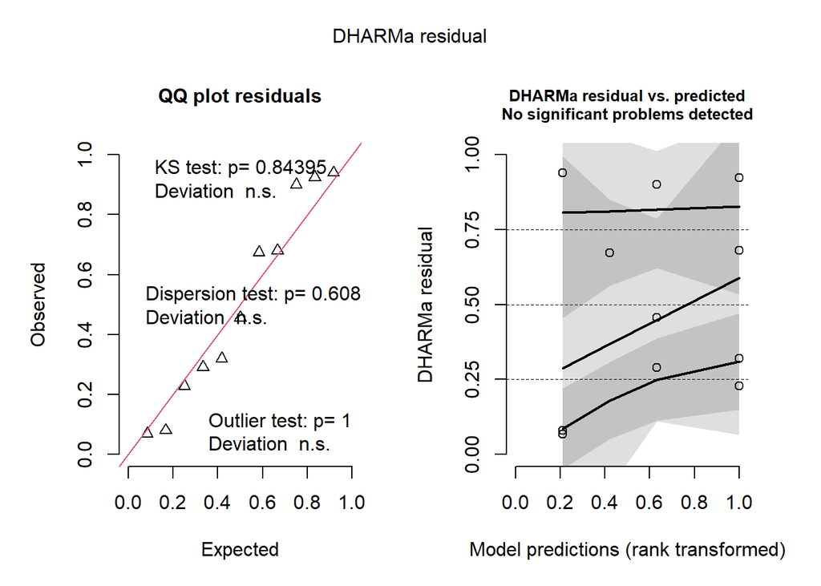

##### PLseedtotal Post-hoc Comparisons with Tukeys HSD

| contrast | trat | estimate | SE | df | z.ratio | p.value |
| --- | --- | --- | --- | --- | --- | --- |
| no - yes | ex | -0.1734441 | 0.9240406 | Inf | -0.1877018 | 0.8511104 |
| no - yes | gra | 0.8007714 | 1.2649544 | Inf | 0.6330437 | 0.5267051 |

| contrast | clip | estimate | SE | df | z.ratio | p.value |
| --- | --- | --- | --- | --- | --- | --- |
| ex - gra | no | -0.8007779 | 0.8631595 | Inf | -0.9277288 | 0.3535483 |
| ex - gra | yes | 0.1734376 | 1.3072552 | Inf | 0.1326731 | 0.8944519 |

ANOVA Results for PLseedtotal Model

| Response | Predictor | Chisq | Df | Pr(>Chisq) |
| --- | --- | --- | --- | --- |
| PL seedtotal | trat | 0.492 | 1 | 0.483 |
| PL seedtotal | clip | 0.049 | 1 | 0.824 |
| PL seedtotal | trat:clip | 0.387 | 1 | 0.534 |

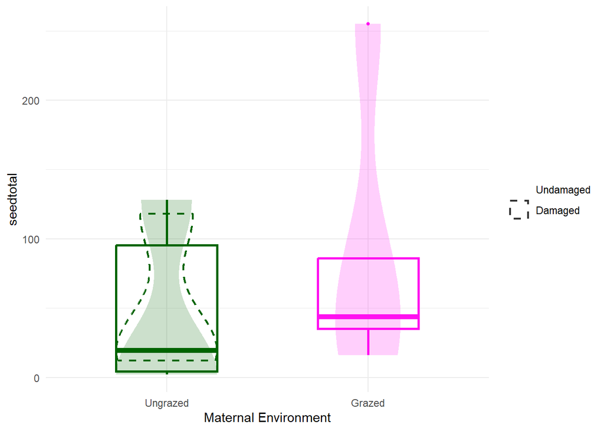

### P.lagopus - PESO MEDIO DE LAS SEMILLAS

**massseed ~ trat + clip + trat:clip**  
n = **10**

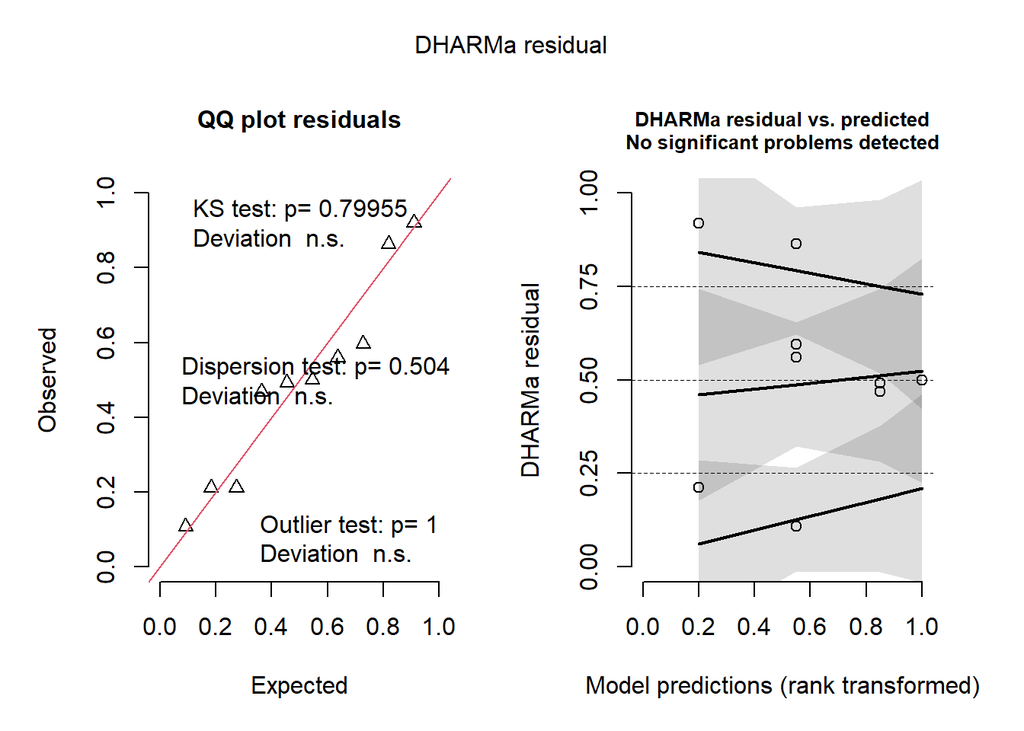

R² = **-0.3004032**

##### PLmassseed Post-hoc Comparisons with Tukeys HSD

| contrast | trat | estimate | SE | df | t.ratio | p.value |
| --- | --- | --- | --- | --- | --- | --- |
| no - yes | ex | -1.0e-04 | 0.0001222 | 6 | -0.8183932 | 0.4444123 |
| no - yes | gra | -2.5e-05 | 0.0001497 | 6 | -0.1670538 | 0.8728156 |

| contrast | clip | estimate | SE | df | t.ratio | p.value |
| --- | --- | --- | --- | --- | --- | --- |
| ex - gra | no | -7.5e-05 | 0.0001022 | 6 | -0.7336252 | 0.4908375 |
| ex - gra | yes | 0.0e+00 | 0.0001639 | 6 | 0.0000000 | 1.0000000 |

ANOVA Results for PLmassseed Model

| Response | Predictor | Sum Sq | Df | F value | Pr(>F) |
| --- | --- | --- | --- | --- | --- |
| PL massseed | trat | 0 | 1 | 0.388 | 0.557 |
| PL massseed | clip | 0 | 1 | 0.547 | 0.487 |
| PL massseed | trat:clip | 0 | 1 | 0.151 | 0.711 |
| PL massseed | Residuals | 0 | 6 | NA | NA |

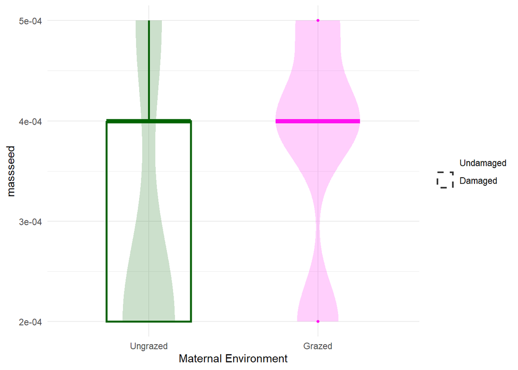

### P.lagopus - SLA

**SLA ~ trat + clip + trat:clip**  
n = **52**

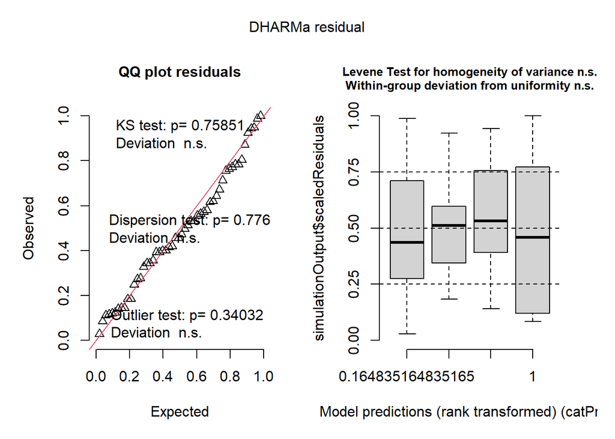

R² = **0.1377018**

##### PLSLA Post-hoc Comparisons with Tukeys HSD

| contrast | trat | estimate | SE | df | t.ratio | p.value |
| --- | --- | --- | --- | --- | --- | --- |
| no - yes | ex | 12.51025 | 23.36577 | 48 | 0.535409 | 0.5948392 |
| no - yes | gra | -67.64691 | 21.55726 | 48 | -3.138011 | 0.0029060 |

| contrast | clip | estimate | SE | df | t.ratio | p.value |
| --- | --- | --- | --- | --- | --- | --- |
| ex - gra | no | 23.60854 | 21.96791 | 48 | 1.074683 | 0.2878893 |
| ex - gra | yes | -56.54862 | 22.98011 | 48 | -2.460763 | 0.0175126 |

ANOVA Results for PLSLA Model

| Response | Predictor | Sum Sq | Df | F value | Pr(>F) |
| --- | --- | --- | --- | --- | --- |
| PL SLA | trat | 2774.787 | 1 | 0.853 | 0.360 |
| PL SLA | clip · | 12284.879 | 1 | 3.776 | 0.058 |
| PL SLA | trat:clip * | 20680.370 | 1 | 6.357 | 0.015 |
| PL SLA | Residuals | 156144.360 | 48 | NA | NA |

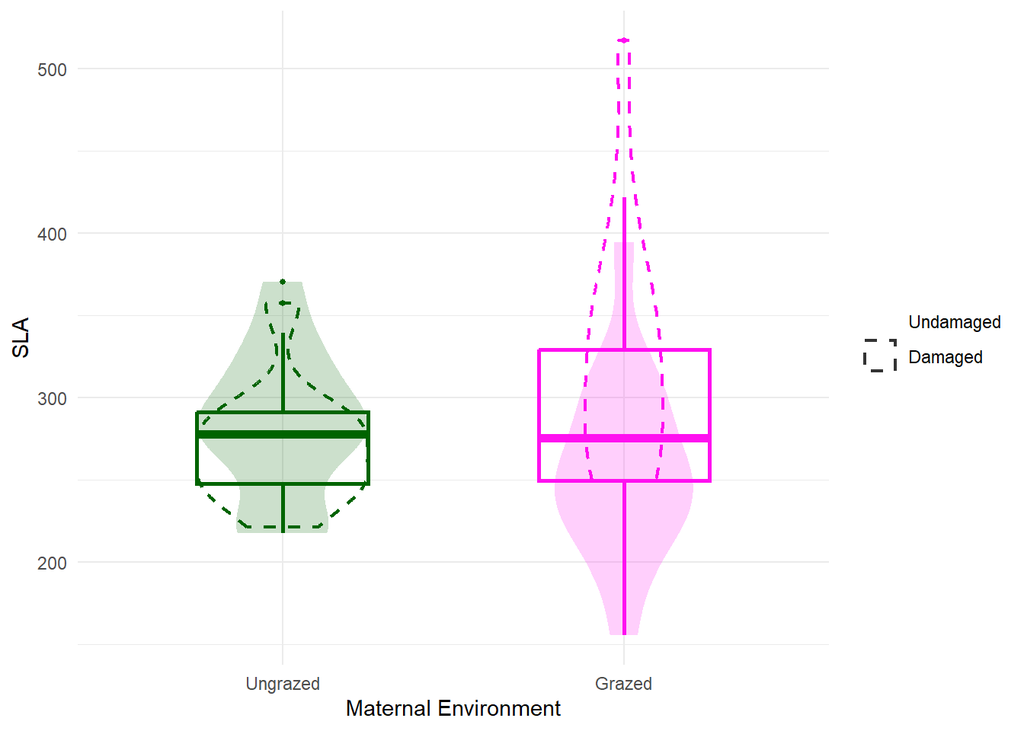

### P.lagopus - LDMC

**LDMC ~ trat + clip + trat:clip**  
n = **52**

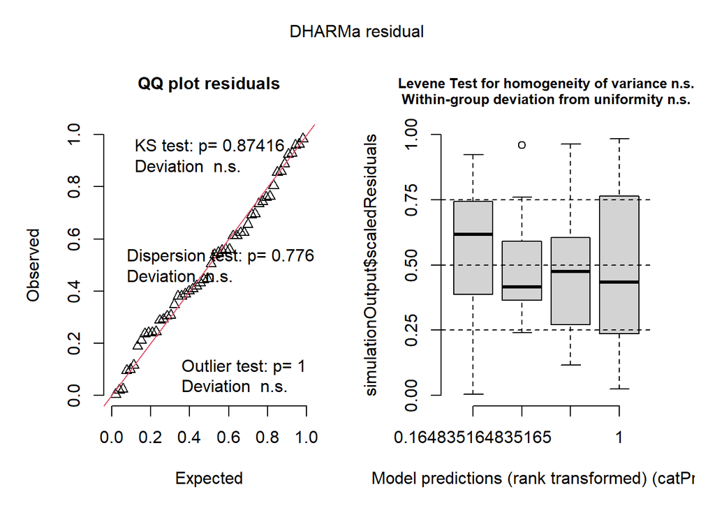

R² = **0.079976**

##### PLLDMC Post-hoc Comparisons with Tukeys HSD

| contrast | trat | estimate | SE | df | t.ratio | p.value |
| --- | --- | --- | --- | --- | --- | --- |
| no - yes | ex | 0.0008979 | 0.0063176 | 48 | 0.1421323 | 0.8875704 |
| no - yes | gra | 0.0150251 | 0.0058490 | 48 | 2.5688249 | 0.0133691 |

| contrast | clip | estimate | SE | df | t.ratio | p.value |
| --- | --- | --- | --- | --- | --- | --- |
| ex - gra | no | -0.0031791 | 0.0060878 | 48 | -0.5222018 | 0.6039316 |
| ex - gra | yes | 0.0109480 | 0.0060878 | 48 | 1.7983478 | 0.0784121 |

ANOVA Results for PLLDMC Model

| Response | Predictor | Sum Sq | Df | F value | Pr(>F) |
| --- | --- | --- | --- | --- | --- |
| PL LDMC | trat | 0.000 | 1 | 0.814 | 0.371 |
| PL LDMC | clip · | 0.001 | 1 | 3.927 | 0.053 |
| PL LDMC | trat:clip | 0.001 | 1 | 2.692 | 0.107 |
| PL LDMC | Residuals | 0.011 | 48 | NA | NA |

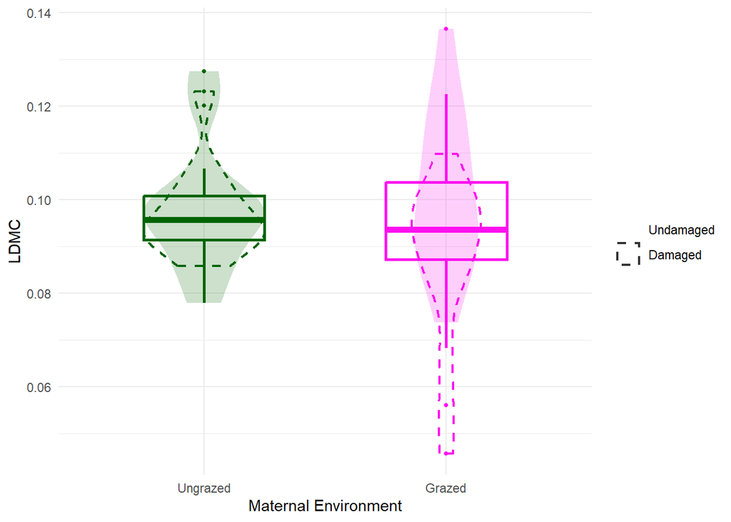

### P.lagopus - ÁREA FOLIAR

**area.m ~ trat + clip + trat:clip**  
n = **53**

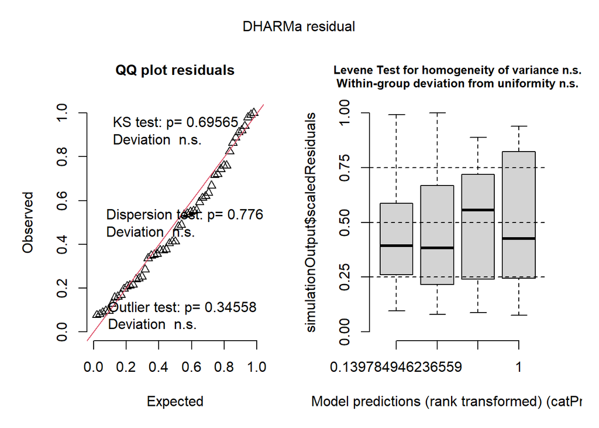

R² = **-0.0531258**

##### PLarea.m Post-hoc Comparisons with Tukeys HSD

| contrast | trat | estimate | SE | df | t.ratio | p.value |
| --- | --- | --- | --- | --- | --- | --- |
| no - yes | ex | 0.5522179 | 1.385359 | 49 | 0.3986101 | 0.6919123 |
| no - yes | gra | 0.3502857 | 1.307993 | 49 | 0.2678039 | 0.7899744 |

| contrast | clip | estimate | SE | df | t.ratio | p.value |
| --- | --- | --- | --- | --- | --- | --- |
| ex - gra | no | -0.2741868 | 1.332910 | 49 | -0.2057055 | 0.8378732 |
| ex - gra | yes | -0.4761190 | 1.361403 | 49 | -0.3497269 | 0.7280424 |

ANOVA Results for PLarea.m Model

| Response | Predictor | Sum Sq | Df | F value | Pr(>F) |
| --- | --- | --- | --- | --- | --- |
| PL area.m | trat | 1.837 | 1 | 0.153 | 0.697 |
| PL area.m | clip | 2.627 | 1 | 0.219 | 0.642 |
| PL area.m | trat:clip | 0.135 | 1 | 0.011 | 0.916 |
| PL area.m | Residuals | 586.820 | 49 | NA | NA |

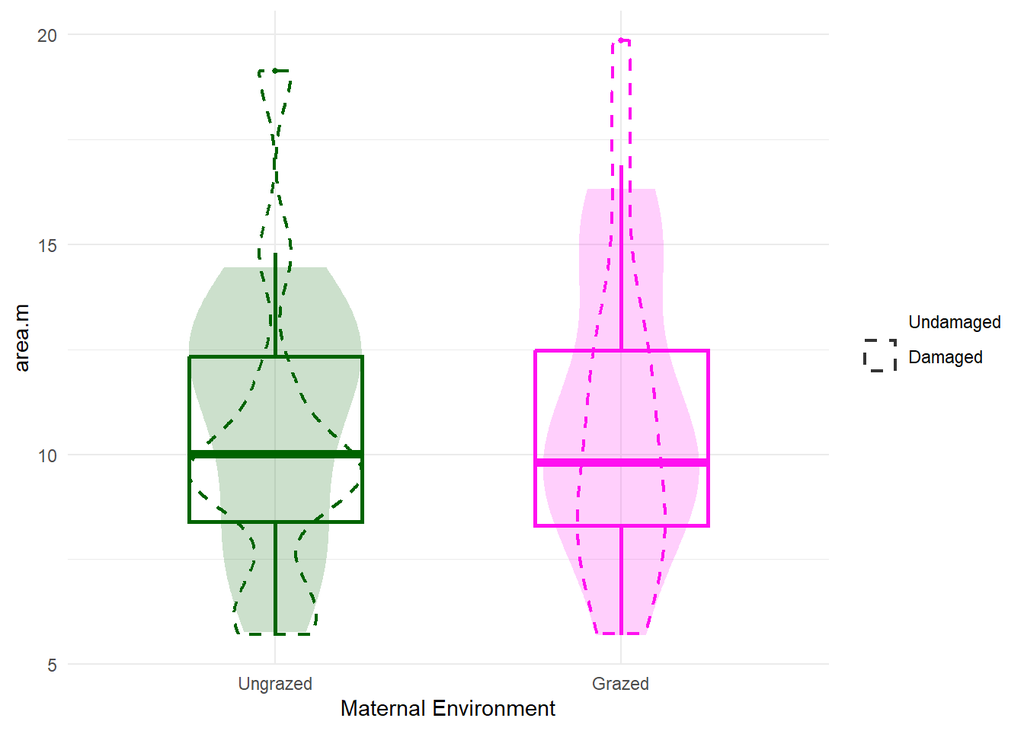

### P.lagopus - TASA FOTOSINTÉTICA

**Photosyn ~ trat + clip + trat:clip**  
n = **30**

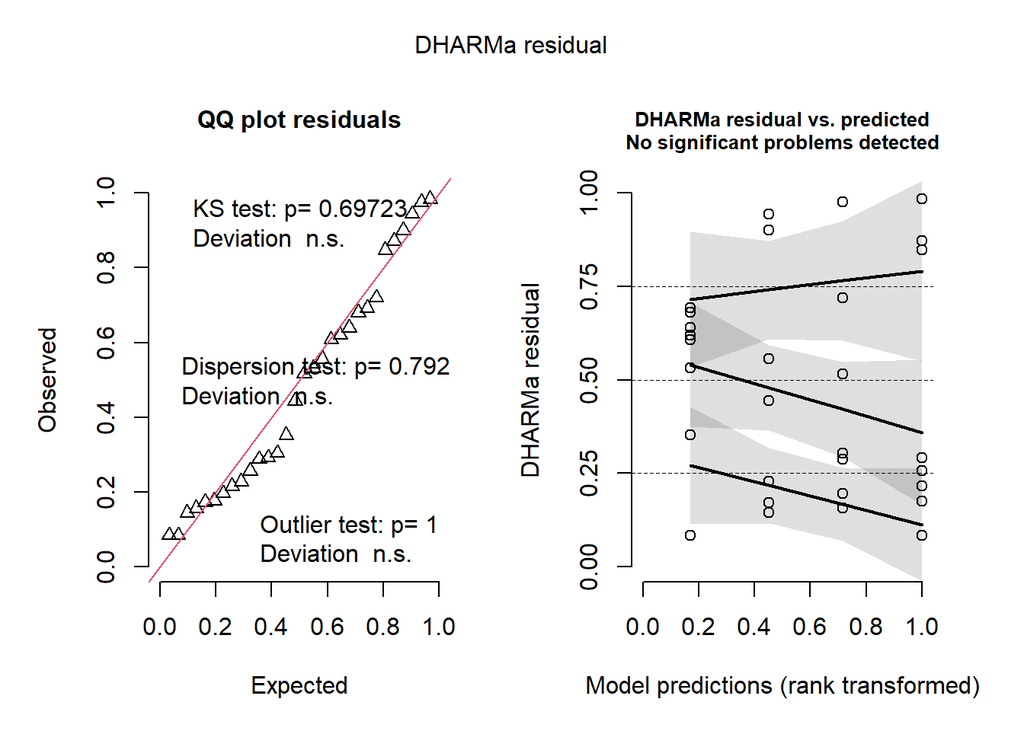

R² = **0.2559066**

##### PLPhotosyn Post-hoc Comparisons with Tukeys HSD

| contrast | trat | estimate | SE | df | t.ratio | p.value |
| --- | --- | --- | --- | --- | --- | --- |
| no - yes | ex | -1.414286 | 2.135512 | 26 | -0.6622702 | 0.5136261 |
| no - yes | gra | -6.737500 | 1.997588 | 26 | -3.3728172 | 0.0023396 |

| contrast | clip | estimate | SE | df | t.ratio | p.value |
| --- | --- | --- | --- | --- | --- | --- |
| ex - gra | no | 4.235714 | 2.0677 | 26 | 2.0485146 | 0.0507307 |
| ex - gra | yes | -1.087500 | 2.0677 | 26 | -0.5259466 | 0.6033830 |

ANOVA Results for PLPhotosyn Model

| Response | Predictor | Sum Sq | Df | F value | Pr(>F) |
| --- | --- | --- | --- | --- | --- |
| PL Photosyn | trat | 18.501 | 1 | 1.159 | 0.292 |
| PL Photosyn | clip ** | 135.681 | 1 | 8.501 | 0.007 |
| PL Photosyn | trat:clip · | 52.895 | 1 | 3.314 | 0.080 |
| PL Photosyn | Residuals | 414.997 | 26 | NA | NA |

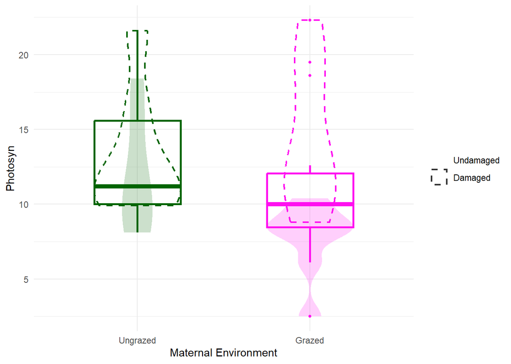

### P.lagopus - CONDUCTANCIA ESTOMÁTICA

**Conductance ~ trat + clip + trat:clip**  
n = **30**

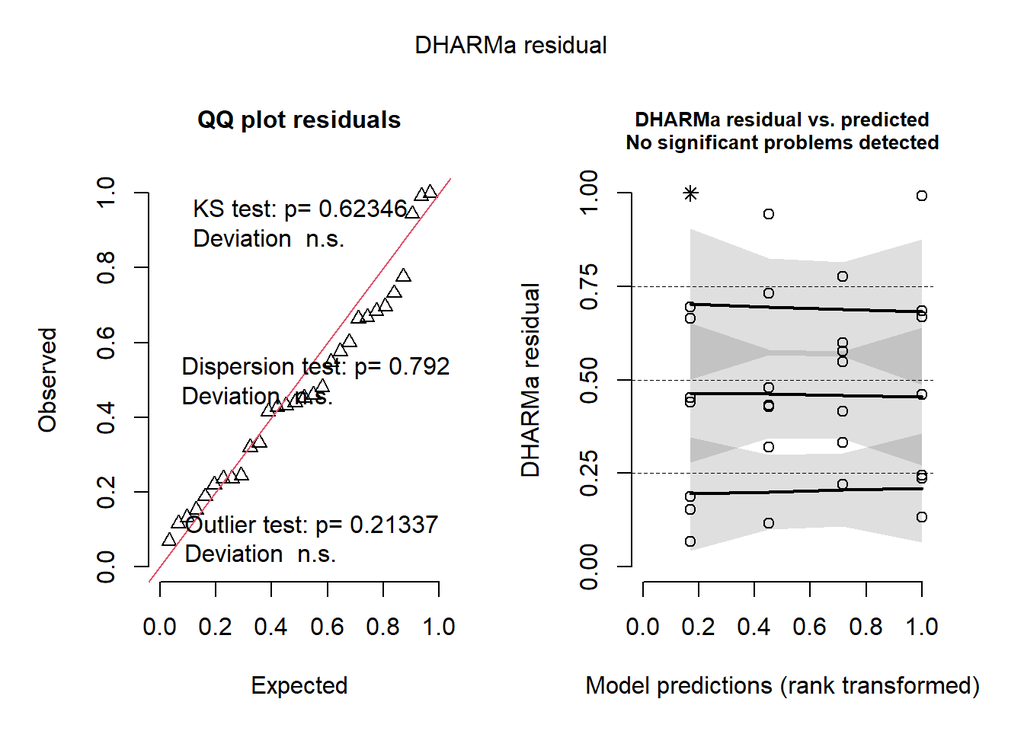

R² = **0.2851853**

##### PLConductance Post-hoc Comparisons with Tukeys HSD

| contrast | trat | estimate | SE | df | t.ratio | p.value |
| --- | --- | --- | --- | --- | --- | --- |
| no - yes | ex | -0.0141429 | 0.0718154 | 26 | -0.1969334 | 0.8454110 |
| no - yes | gra | -0.2193750 | 0.0671772 | 26 | -3.2656184 | 0.0030604 |

| contrast | clip | estimate | SE | df | t.ratio | p.value |
| --- | --- | --- | --- | --- | --- | --- |
| ex - gra | no | 0.0059286 | 0.069535 | 26 | 0.0852603 | 0.9327076 |
| ex - gra | yes | -0.1993036 | 0.069535 | 26 | -2.8662348 | 0.0081229 |

ANOVA Results for PLConductance Model

| Response | Predictor | Sum Sq | Df | F value | Pr(>F) |
| --- | --- | --- | --- | --- | --- |
| PL Conductance | trat · | 0.070 | 1 | 3.867 | 0.060 |
| PL Conductance | clip * | 0.115 | 1 | 6.347 | 0.018 |
| PL Conductance | trat:clip * | 0.079 | 1 | 4.356 | 0.047 |
| PL Conductance | Residuals | 0.469 | 26 | NA | NA |

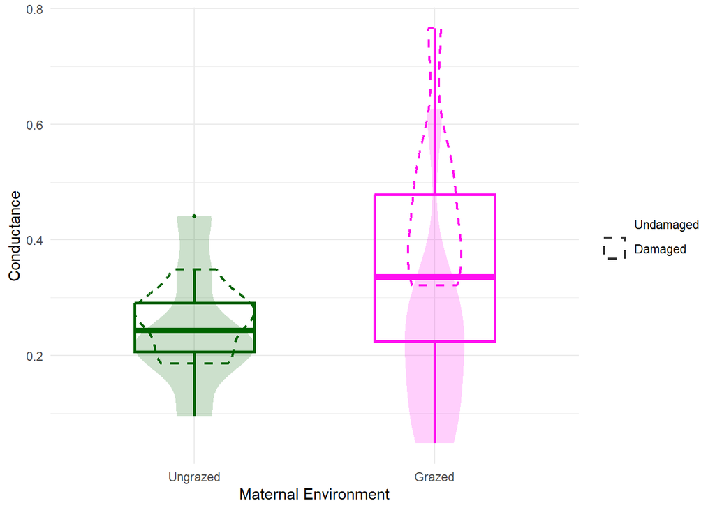

### P.lagopus - EFICIENCIA DEL FOTOSISTEMA II

**PhiPS2 ~ trat + clip + trat:clip**  
n = **30**

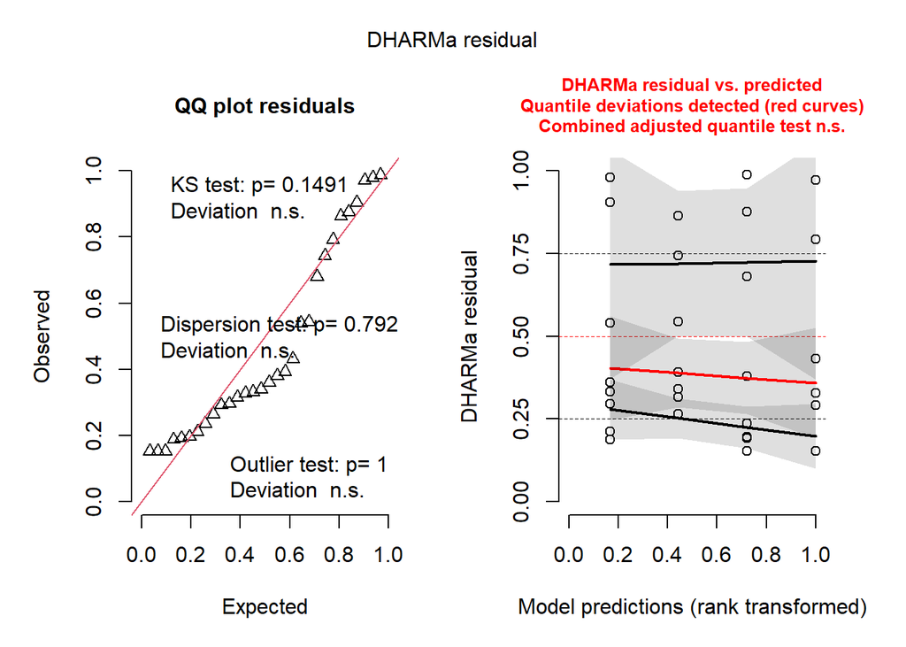

R² = **0.0587555**

##### PLPhiPS2 Post-hoc Comparisons with Tukeys HSD

| contrast | trat | estimate | SE | df | t.ratio | p.value |
| --- | --- | --- | --- | --- | --- | --- |
| no - yes | ex | -0.041 | 0.0356174 | 26 | -1.151122 | 0.2601584 |
| no - yes | gra | -0.059 | 0.0333170 | 26 | -1.770866 | 0.0883077 |

| contrast | clip | estimate | SE | df | t.ratio | p.value |
| --- | --- | --- | --- | --- | --- | --- |
| ex - gra | no | 0.0234107 | 0.0344864 | 26 | 0.6788388 | 0.5032384 |
| ex - gra | yes | 0.0054107 | 0.0344864 | 26 | 0.1568941 | 0.8765403 |

ANOVA Results for PLPhiPS2 Model

| Response | Predictor | Sum Sq | Df | F value | Pr(>F) |
| --- | --- | --- | --- | --- | --- |
| PL PhiPS2 | trat | 0.002 | 1 | 0.349 | 0.560 |
| PL PhiPS2 | clip * | 0.019 | 1 | 4.325 | 0.048 |
| PL PhiPS2 | trat:clip | 0.001 | 1 | 0.136 | 0.715 |
| PL PhiPS2 | Residuals | 0.115 | 26 | NA | NA |

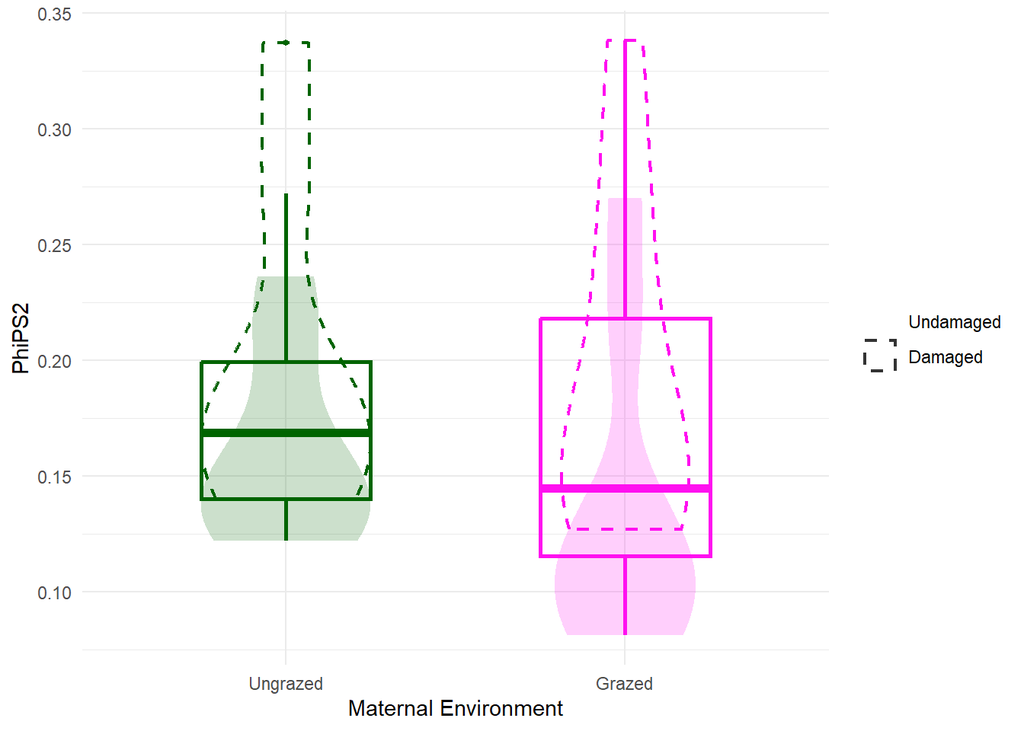

### P.lagopus - FENOLOGÍA DE FLORACIÓN

**dias_flor ~ trat + clip + trat:clip**  
n = **18**

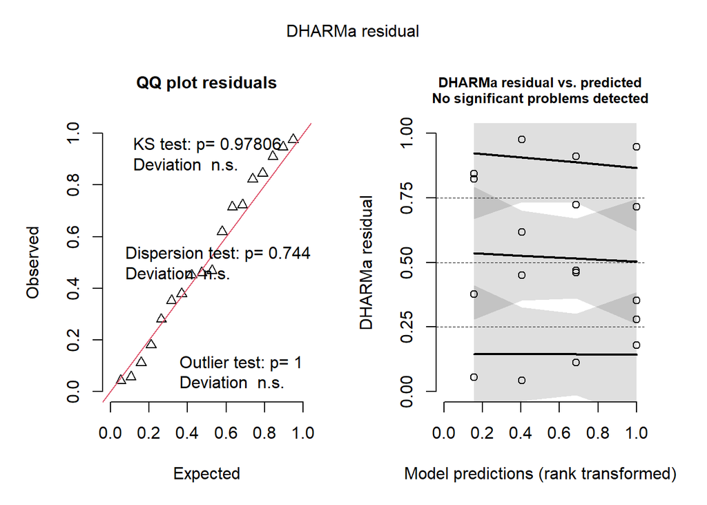

##### PLdias_flor Post-hoc Comparisons with Tukeys HSD

| contrast | trat | estimate | SE | df | z.ratio | p.value |
| --- | --- | --- | --- | --- | --- | --- |
| no - yes | ex | 0.0074625 | 0.1184748 | Inf | 0.0629878 | 0.9497763 |
| no - yes | gra | -0.0796031 | 0.1355609 | Inf | -0.5872131 | 0.5570606 |

| contrast | clip | estimate | SE | df | z.ratio | p.value |
| --- | --- | --- | --- | --- | --- | --- |
| ex - gra | no | 0.2067822 | 0.1277062 | Inf | 1.6192030 | 0.1054036 |
| ex - gra | yes | 0.1197166 | 0.1269022 | Inf | 0.9433769 | 0.3454882 |

ANOVA Results for PLdias_flor Model

| Response | Predictor | Chisq | Df | Pr(>Chisq) |
| --- | --- | --- | --- | --- |
| PL dias_flor | trat · | 3.278 | 1 | 0.070 |
| PL dias_flor | clip | 0.115 | 1 | 0.735 |
| PL dias_flor | trat:clip | 0.234 | 1 | 0.629 |

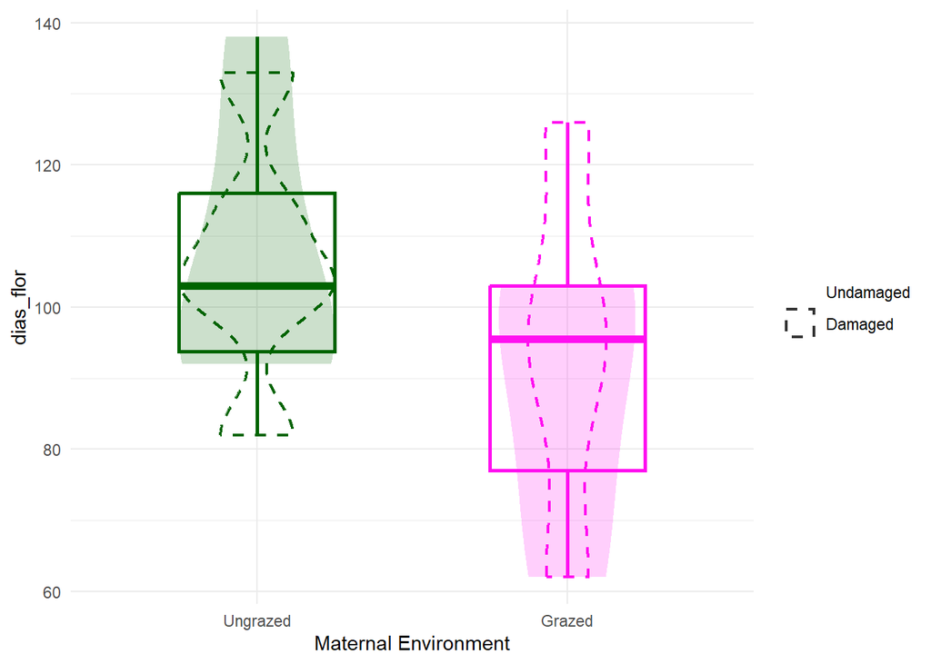

### P.lagopus - FENOLOGÍA DE FRUCTIFICACÓN

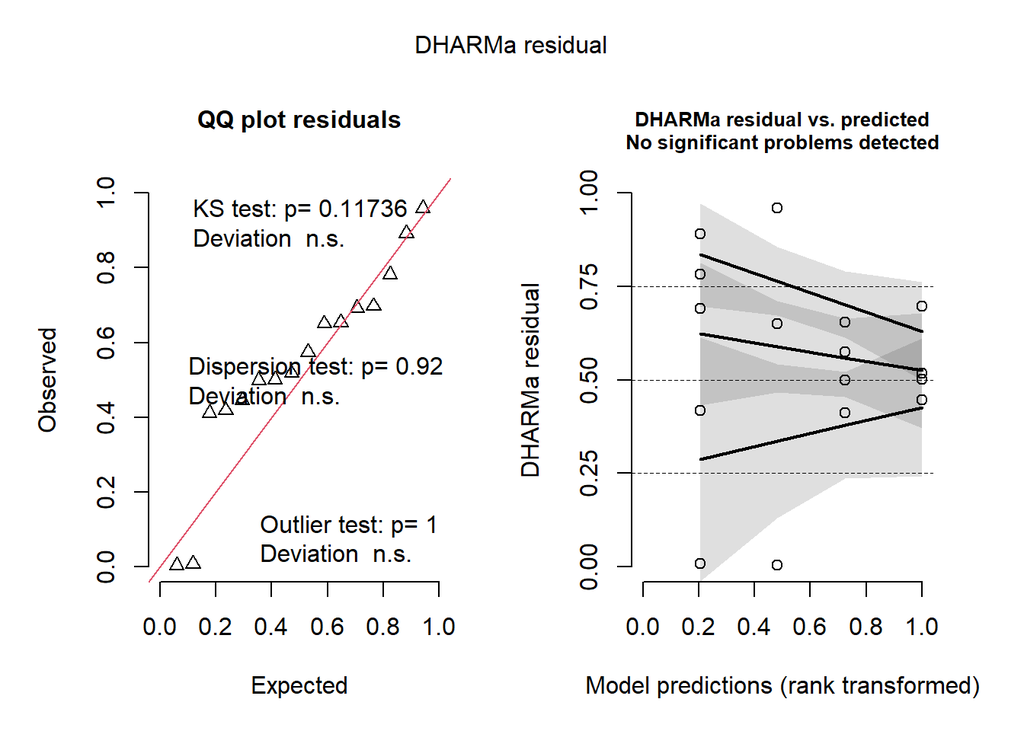

##### PLdias_fruto Post-hoc Comparisons with Tukeys HSD

| contrast | trat | estimate | SE | df | z.ratio | p.value |
| --- | --- | --- | --- | --- | --- | --- |
| no - yes | ex | 0.0059702 | 0.1237923 | Inf | 0.0482273 | 0.9615351 |
| no - yes | gra | -0.0596223 | 0.1295794 | Inf | -0.4601212 | 0.6454292 |

| contrast | clip | estimate | SE | df | z.ratio | p.value |
| --- | --- | --- | --- | --- | --- | --- |
| ex - gra | no | 0.1394445 | 0.1184014 | Inf | 1.1777268 | 0.2389056 |
| ex - gra | yes | 0.0738521 | 0.1345231 | Inf | 0.5489921 | 0.5830109 |

ANOVA Results for PLdias_fruto Model

| Response | Predictor | Chisq | Df | Pr(>Chisq) |
| --- | --- | --- | --- | --- |
| PL dias_fruto | trat | 1.554 | 1 | 0.212 |
| PL dias_fruto | clip | 0.080 | 1 | 0.777 |
| PL dias_fruto | trat:clip | 0.134 | 1 | 0.714 |

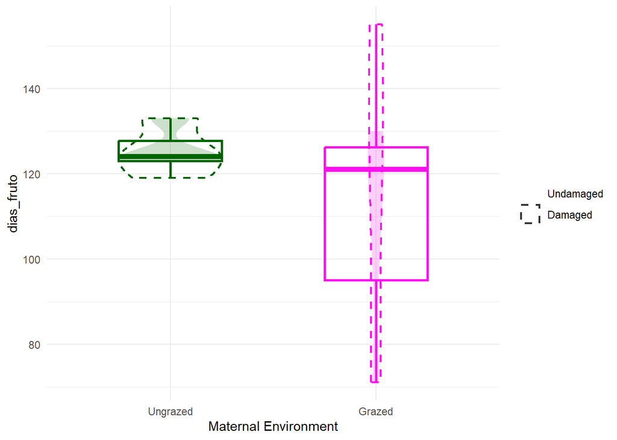

### P.lagopus - PERIODO DE FLORACIÓN

**periodo_flor ~ trat + clip + trat:clip**  
n = **3** no hay modelo que valga. La mayoría de plantas de esta especie ni siquiera empezaron a florecer cuando las cosechamos para la epigenética :(

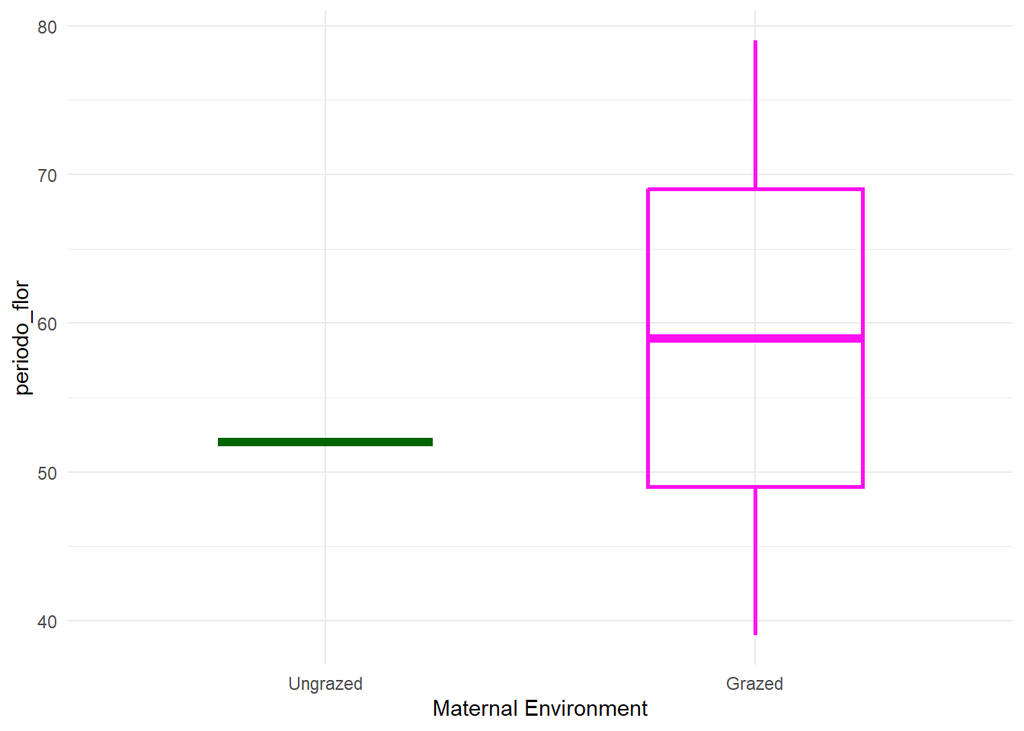